# Metadatos ICFES

icfes: competencia: - interpretacion_representacion - formulacion_ejecucion nivel_dificultad: 3 contenido: categoria: estadistica tipo: generico contexto: comunitario eje_axial: eje4 componente: aleatorio

# Question

Se ha entrevistado a 43 adolescentes sobre los géneros musicales que escuchan.

- 17 de ellos escuchan Electrónica,
- 17 escuchan Salsa, y
- 25 Cumbia.

Además sabemos que

- 2 de ellos escuchan solamente Electrónica y Salsa,
- 7 escuchan Electrónica y Cumbia, y
- 7 Salsa y Cumbia.

Por último sabemos que solamente 3 escuchan los tres géneros musicales.

Considerando esa información:

## Answerlist

- ¿Cuántas personas escuchan solamente Electrónica y Salsa?
- ¿Cuál es el total de personas que escuchan solo uno de estos géneros musicales?
- ¿Cuántos adolescentes escuchan al menos uno de estos géneros musicales?
- ¿Cuántas personas escuchan los tres géneros musicales?

# Solution

Para resolver este problema, analizamos el diagrama de Venn que representa la intersección de los tres conjuntos: Electrónica, Salsa y Cumbia.

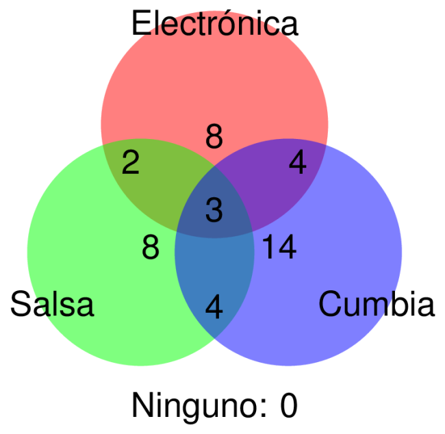

Explicación detallada:

1. ¿Cuántas personas escuchan solamente Electrónica y Salsa?: 2
2. ¿Cuál es el total de personas que escuchan solo uno de estos géneros musicales?: 30
3. ¿Cuántos adolescentes escuchan al menos uno de estos géneros musicales?: 43
4. ¿Cuántas personas escuchan los tres géneros musicales?: 3

## Answerlist

- La respuesta es 2.
- La respuesta es 30.
- La respuesta es 43.
- La respuesta es 3.

# Meta-information

exname: Géneros musicales extype: cloze exclozetype: num|num|num|num exsolution: 2|30|43|3 extol: 0 exsection: Diagrama de Venn